# City Population Growth Rate Analysis: A reflection of STAT 631 01

Eric Opoku

2024-08-06

### Introduction

To measure my progress and commitment to this course, I used this project to demonstrate how well I understood the objectives. The purpose of this work is to analyze and understand the trends and factors influencing population growth rates across various cities globally. This portfolio includes a comprehensive examination of simple and multiple linear regression models, as well as logistic regression for classification, to predict and analyze population growth rates. This enables me to experiment with and evaluate my understanding of the course objective

### Project Motivation

In a rapidly urbanizing world, understanding the dynamics of population growth in cities is crucial for planning and policy-making. Population growth affects various aspects of urban life, including infrastructure, economy, environment, and social services. By analyzing the growth rates of cities, we can gain insights into trends and patterns that help in making informed decisions for sustainable development. This motivation was sure to solve a real world problem, which pushed me to apply the skills acquired to investigate.

### Import the data set

In this section, I learned how to import a CSV file in R and use it for analysis. The data provides information on the population and growth rates of various cities around the world for 2024.

```r
world_population_growth_rate_data <- read_csv("World population growth rate by cities 2024.csv")
```

```r
data <- world_population_growth_rate_data
```

**Data Dictionary** n my quest to improve using R, I learned how to represent my data in my output file as a data dictionary. In this section, the data dictionary has been used to describe the data used in this work.

```r
# Create the initial data dictionary manually
data_dictionary <- data.frame(
  Variable_Name = c("City", "Country", "Continent", "Population (2024)", "Population (2023)", "Growth Rate"),
  Data_Type = c("String", "String", "String", "Integer", "Integer", "Float"),
  Description = c("Name of the city",
                  "Country where the city is located",
                  "Continent where the city is located",
                  "Projected population for the city in 2024",
                  "Population of the city in 2023",
                  "Population growth rate of the city from 2023 to 2024")
)

# Extract Data Type and Class from the dataset
data_types <- sapply(world_population_growth_rate_data, typeof)
data_classes <- sapply(world_population_growth_rate_data, class)

# Add the extracted Data Type and Class to the data dictionary
data_dictionary$Data_Type_Extracted <- data_types[data_dictionary$Variable_Name]
data_dictionary$Class_Extracted <- data_classes[data_dictionary$Variable_Name]

# Print the data dictionary using flextable
flextable(data_dictionary) |>
  set_caption("Table 1: Data Dictionary for World Population Growth Rate Data") |>
  autofit()
```

Table 1: Data Dictionary for World Population Growth Rate Data

| Variable_Name | Data_Type | Description | Data_Type_Extracted | Class_Extracted |
| --- | --- | --- | --- | --- |
| City | String | Name of the city | character | character |
| Country | String | Country where the city is located | character | character |
| Continent | String | Continent where the city is located | character | character |
| Population (2024) | Integer | Projected population for the city in 2024 | double | numeric |
| Population (2023) | Integer | Population of the city in 2023 | double | numeric |
| Growth Rate | Float | Population growth rate of the city from 2023 to 2024 | double | numeric |

### Data Exploration and Preprocessing

Further, to do any modeling, it is essential to explore the data, clean it, shape it, and understand it before deciding on the modeling technique. I used this process to explore the world population growth data, understand it, and prepare it for statistical modeling. This technique has become a valuable tool in my skill set. Since this process is known to be crucial, I visualized missing values, checked basic statistics, and cleaned the data.

```r
skim(data)
```

Data summary

| Name | data |
| --- | --- |
| Number of rows | 801 |
| Number of columns | 6 |
| _______________________ |  |
| Column type frequency: |  |
| character | 3 |
| numeric | 3 |
| ________________________ |  |
| Group variables | None |

**Variable type: character**

| skim_variable | n_missing | complete_rate | min | max | empty | n_unique | whitespace |
| --- | --- | --- | --- | --- | --- | --- | --- |
| City | 0 | 1.00 | 3 | 24 | 0 | 797 | 0 |
| Country | 0 | 1.00 | 4 | 24 | 0 | 132 | 0 |
| Continent | 11 | 0.99 | 4 | 13 | 0 | 7 | 0 |

**Variable type: numeric**

| skim_variable | n_missing | complete_rate | mean | sd | p0 | p25 | p50 | p75 | p100 | hist |
| --- | --- | --- | --- | --- | --- | --- | --- | --- | --- | --- |
| Population (2024) | 0 | 1 | 2654327.33 | 3723253.28 | 750036.00 | 990931.00 | 1379368.00 | 2570980.00 | 37115035.00 | ▇▁▁▁▁ |
| Population (2023) | 0 | 1 | 2604461.23 | 3661200.83 | 722836.00 | 969804.00 | 1363510.00 | 2514077.00 | 37194105.00 | ▇▁▁▁▁ |
| Growth Rate | 0 | 1 | 0.02 | 0.01 | -0.02 | 0.01 | 0.02 | 0.03 | 0.06 | ▁▂▇▃▁ |

**Basic Statistics of the Data**

- The data set includes 801 cities.
- The mean population for 2024 is approximately 2.65 million, with a standard deviation of around 3.72 million.
- The growth rate ranges from -0.0249 to 0.0582, with a mean of 0.0201.
- The Continent explanatory variable is missing 11 data points. This issue will be addressed

**Visusalizing the Missigness of the data**

```r
data |>

  gg_miss_var(show_pct = TRUE) +

  labs(title = "Missingness of World population growth rate by cities 2024 ") +

  ggthemes::theme_few()
```

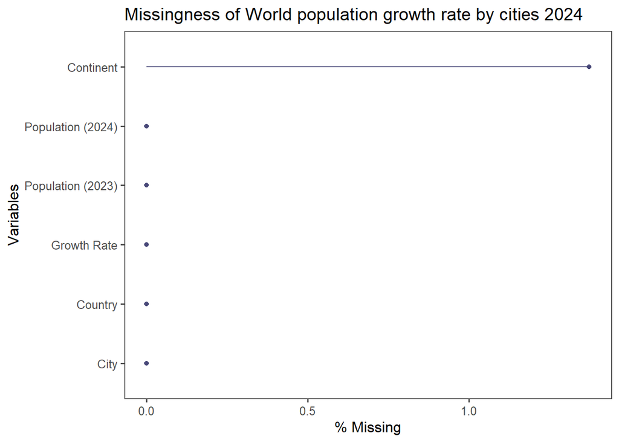

The missingness graph indicates that the missing data points account for less than 1.5% of the total. This percentage is considered insignificant, so these rows will be excluded from the analysis.

**Handling the Missing Values**

```r
# Drop rows with missing values
world_population_growth_rate_data <- na.omit(world_population_growth_rate_data)
```

**Checking for Inconsistencies Character Variables**

```r
# View the names of the variables
variable_names <- names(data)

# Print the variable names
print(variable_names)
```

```
## [1] "City"              "Country"           "Continent"
## [4] "Population (2024)" "Population (2023)" "Growth Rate"
```

The data variables are consistent

```r
# Check the unique entries in the 'continent' variable
unique_continents <- unique(data$Continent)

# Print the unique entries
print(unique_continents)
```

```
## [1] "Asia"          "South America" "Africa"        "North America"
## [5] "Europe"        "Oceana"        NA              "Oceania"
```

Remove move the NA, because is unknown and Standardize the Oceana

```r
# Remove rows where the continent is NA and standardize "Oceana" to "Oceania"
data <- data %>%
  filter(!is.na(Continent)) %>%
  mutate(Continent = ifelse(Continent == "Oceana", "Oceania", Continent))

# Check the unique entries to verify the changes
unique_continents <- unique(data$Continent)
print(unique_continents)
```

```
## [1] "Asia"          "South America" "Africa"        "North America"
## [5] "Europe"        "Oceania"
```

This data is basically consistent for further exploration

### Initial Analysis

**Correlation Analysis**

In this section, `Correlation Analysis` is performed to further understand the data

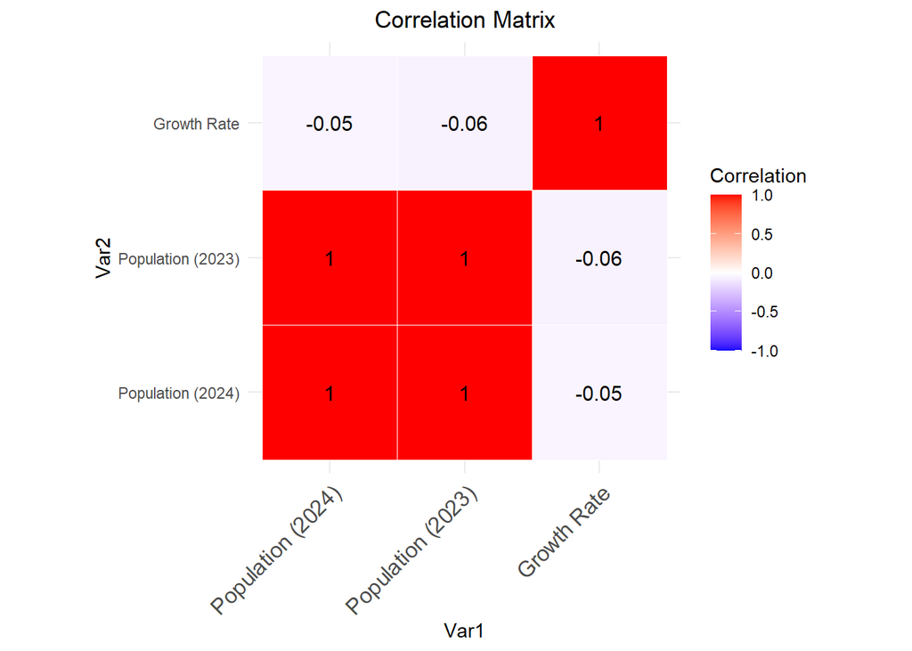

```r
# Calculate the correlation matrix
correlation_matrix <- cor(world_population_growth_rate_data[, c("Population (2024)", "Population (2023)", "Growth Rate")])

# Melt the correlation matrix into long format
melted_correlation_matrix <- melt(correlation_matrix)

# Plot the correlation matrix
ggplot(data = melted_correlation_matrix, aes(x = Var1, y = Var2, fill = value)) +
  geom_tile(color = "white") +
  scale_fill_gradient2(low = "blue", high = "red", mid = "white", midpoint = 0, limit = c(-1, 1), space = "Lab",
                       name = "Correlation") +
  theme_minimal() +
  theme(axis.text.x = element_text(angle = 45, vjust = 1, size = 12, hjust = 1)) +
  coord_fixed() +
  geom_text(aes(label = round(value, 2)), color = "black", size = 4) + # Add correlation scores
  ggtitle("Correlation Matrix") +
  theme(plot.title = element_text(hjust = 0.5))
```

**Correlation Analysis Insights**

The correlation matrix reveals the following:

- There is a perfect correlation (1.0) between the population in 2023 and 2024. This is expected because the 2024 population is derived from the 2023 population and the growth rate.
  - **Interpretation:** The population numbers for 2023 and 2024 are directly linked, so it’s no surprise they match up perfectly in our analysis.
- The growth rate has a weak negative correlation with both the 2023 and 2024 populations (approximately -0.05).
  - **Interpretation:** There’s a very slight tendency for cities with larger populations to have slightly lower growth rates, but this relationship is very weak.

### Distribution Analysis

In this section `Distribution Analysis` of Population in `2023`, `2024` and the distribution of `Growth Rates` is performed

Distribution of Population in `2023` and `2024`

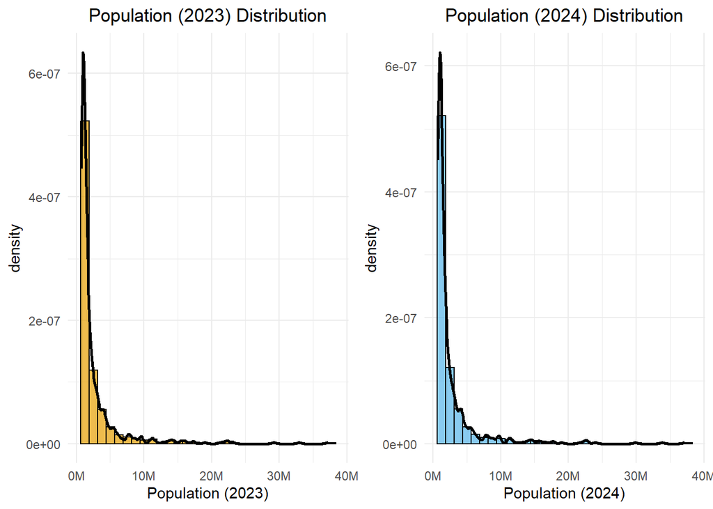

```r
# Set colors for color blindness friendliness
color_population_2023 <- "#E69F00"  # Orange
color_population_2024 <- "#56B4E9"  # Light blue
color_growth_rate <- "#009E73"      # Green

# Custom label function for millions
label_millions <- label_number(scale = 1e-6, suffix = "M")

# Histogram for Population in 2023
p1 <- ggplot(data, aes(x = `Population (2023)`)) +
  geom_histogram(aes(y = ..density..), bins = 30, fill = color_population_2023, color = "black", alpha = 0.7) +
  geom_density(color = "black", size = 1) +
  ggtitle('Population (2023) Distribution') +
  theme_minimal() +
  scale_x_continuous(labels = label_millions) + # Use millions label
  theme(plot.title = element_text(hjust = 0.5))

# Histogram for Population in 2024
p2 <- ggplot(data, aes(x = `Population (2024)`)) +
  geom_histogram(aes(y = ..density..), bins = 30, fill = color_population_2024, color = "black", alpha = 0.7) +
  geom_density(color = "black", size = 1) +
  ggtitle('Population (2024) Distribution') +
  theme_minimal() +
  scale_x_continuous(labels = label_millions) + # Use millions label
  theme(plot.title = element_text(hjust = 0.5))

# Arrange the plots in a grid
grid.arrange(p1, p2, ncol = 2)
```

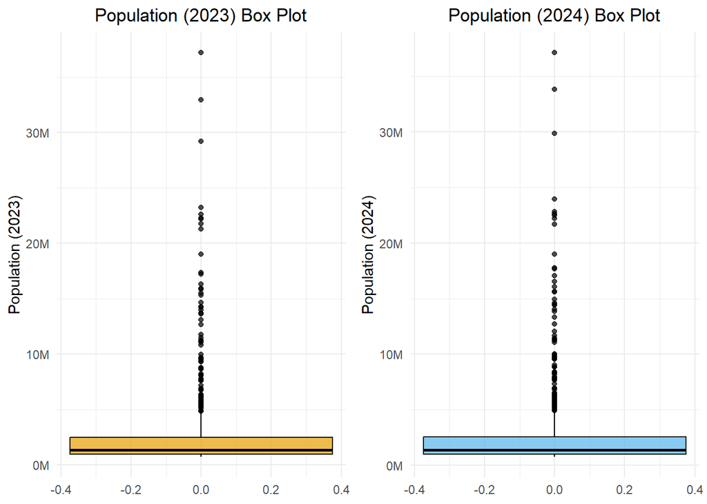

```r
# Distribution of Population in `2023` and `2024`
# Box plot for Population in 2023
p4 <- ggplot(data, aes(y = `Population (2023)`)) +
  geom_boxplot(fill = color_population_2023, color = "black", alpha = 0.7) +
  ggtitle('Population (2023) Box Plot') +
  theme_minimal() +
  scale_y_continuous(labels = label_millions) + # Use millions label
  theme(plot.title = element_text(hjust = 0.5))

# Box plot for Population in 2024
p5 <- ggplot(data, aes(y = `Population (2024)`)) +
  geom_boxplot(fill = color_population_2024, color = "black", alpha = 0.7) +
  ggtitle('Population (2024) Box Plot') +
  theme_minimal() +
  scale_y_continuous(labels = label_millions) + # Use millions label
  theme(plot.title = element_text(hjust = 0.5))

# Arrange the plots in a grid
grid.arrange(p4, p5, ncol = 2)
```

**Distribution Analysis Insights**

- Both 2023 and 2024 populations show a right-skewed distribution, indicating that most cities have populations on the lower end, with a few cities having very high populations.
  - **Interpretation:** Most cities have smaller populations, but there are a few very large cities that push the distribution to the right.
- The box plots confirm the presence of outliers (cities with exceptionally high populations).
  - **Interpretation:** There are some cities with populations much higher than the rest, which are considered outliers

**Distribution of Growth Rate**

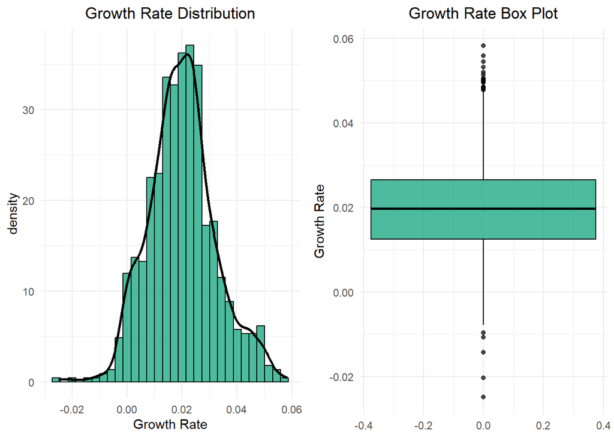

```r
# Histogram for Growth Rate
p3 <- ggplot(data, aes(x = `Growth Rate`)) +
  geom_histogram(aes(y = ..density..), bins = 30, fill = color_growth_rate, color = "black", alpha = 0.7) +
  geom_density(color = "black", size = 1) +
  ggtitle('Growth Rate Distribution') +
  theme_minimal() +
  theme(plot.title = element_text(hjust = 0.5))

# Box plot for Growth Rate
p6 <- ggplot(data, aes(y = `Growth Rate`)) +
  geom_boxplot(fill = color_growth_rate, color = "black", alpha = 0.7) +
  ggtitle('Growth Rate Box Plot') +
  theme_minimal() +
  theme(plot.title = element_text(hjust = 0.5))

# Arrange the plots in a grid
grid.arrange(p3, p6, ncol = 2)
```

**Growth Rate Distribution Insight**

- The growth rate distribution is fairly symmetrical and centered around the mean growth rate (0.0201).
  - **Interpretation:** Most cities have a growth rate close to the average, with an even spread of cities growing faster or slower.
- The box plot shows that the growth rates also have some outliers, with a few cities experiencing significantly higher or lower growth rates.
  - **interpretation:** While most cities grow at a steady rate, some cities grow much faster or slower than others, creating outliers.

**Growth Rate Analysis by Continent**

In this section we investigate how `Growth rates` vary across different `continents`.

**Variation in Growth Rate**

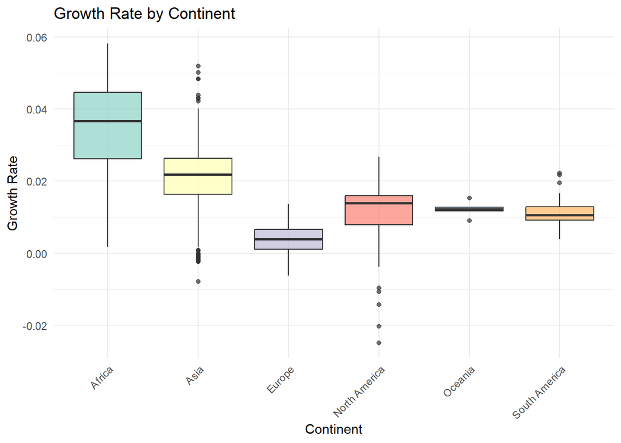

```r
# color palette for continents
color_palette <- brewer.pal(n = 7, name = "Set3")

# Box plot of growth rates by continent
p <- ggplot(data, aes(x = Continent, y = `Growth Rate`, fill = Continent)) +
  geom_boxplot(alpha = 0.7) +
  scale_fill_manual(values = color_palette) +
  ggtitle('Growth Rate by Continent') +
  theme_minimal() +
  theme(axis.text.x = element_text(angle = 45, hjust = 1), legend.position = "none")

# Print the plot
print(p)
```

## Growth Rate Analysis by Continent Insights

- **Africa** has the highest variability in growth rates, with several cities experiencing significantly higher growth rates compared to other continents.  
  **Interpretation:** This means that while some cities in Africa are growing very rapidly, others might be growing more slowly.
- **Asia** also shows relatively high growth rates, but with less variability compared to Africa.  
  **Interpretation:** Many cities in Asia are growing steadily, though not as unevenly as in Africa.
- **Europe** shows the lowest growth rates, with many cities experiencing minimal or even negative growth.  
  **Interpretation:** Europe’s population growth is generally slower, with some cities possibly even shrinking.

**Mean Growth Rate by Continent**

```r
# Calculate mean growth rate by continent
mean_growth_by_continent <- aggregate(`Growth Rate` ~ Continent, data = data, mean)

# Display the mean growth rate by continent using flextable
mean_growth_by_continent_ft <- flextable(mean_growth_by_continent)
mean_growth_by_continent_ft <- set_caption(mean_growth_by_continent_ft, "Mean Growth Rate by Continent")
mean_growth_by_continent_ft <- autofit(mean_growth_by_continent_ft)

# Print the flextable
mean_growth_by_continent_ft
```

Mean Growth Rate by Continent

| Continent | Growth Rate |
| --- | --- |
| Africa | 0.034478302 |
| Asia | 0.021123000 |
| Europe | 0.003849057 |
| North America | 0.010619048 |
| Oceania | 0.012233333 |
| South America | 0.011275806 |

### Insights from Mean Growth Rate

- **Africa** has the highest mean growth rate (0.034478), followed by **Asia** (0.021123).  
  **Interpretation:** On average, cities in Africa are growing faster than those in other continents.
- **Europe** has the lowest mean growth rate (0.003849).  
  **Interpretation:** European cities are growing very slowly or not at all, and some might even be decreasing in population.

# Statistical Modelling

During this course, I have learned to apply statistical models to real-world data, aligning with the course objectives.

**Simple Linear Regression**

In this section, I started with linear regression to model the relationship between population size and growth rate. Specifically, we will develop a simple linear regression model where the dependent variable is the `Growth Rate`, and the independent variable is the `Population (2023)` of each city.

```r
# Data preparation: transform the yearly population data
data$Log_Population_2023 <- log(data$`Population (2023)`)
data$Log_Population_2024 <- log(data$`Population (2024)`)

# Develop a simple linear regression model
model <- lm(`Growth Rate` ~ `Population (2023)`, data = data)

# Summarize the model
summary(model)
```

```
##
## Call:
## lm(formula = `Growth Rate` ~ `Population (2023)`, data = data)
##
## Residuals:
##       Min        1Q    Median        3Q       Max
## -0.043963 -0.007665 -0.000211  0.006527  0.037863
##
## Coefficients:
##                       Estimate Std. Error t value Pr(>|t|)
## (Intercept)          2.056e-02  5.295e-04  38.824   <2e-16 ***
## `Population (2023)` -1.839e-10  1.173e-10  -1.568    0.117
## ---
## Signif. codes:  0 '***' 0.001 '**' 0.01 '*' 0.05 '.' 0.1 ' ' 1
##
## Residual standard error: 0.01213 on 788 degrees of freedom
## Multiple R-squared:  0.00311,    Adjusted R-squared:  0.001845
## F-statistic: 2.458 on 1 and 788 DF,  p-value: 0.1173
```

```r
tidy_model <- tidy(model)
print(tidy_model)
```

```
## # A tibble: 2 × 5
##   term                 estimate std.error statistic   p.value
##   <chr>                   <dbl>     <dbl>     <dbl>     <dbl>
## 1 (Intercept)          2.06e- 2  5.30e- 4     38.8  4.02e-185
## 2 `Population (2023)` -1.84e-10  1.17e-10     -1.57 1.17e-  1
```

```r
# Predict growth rates using the model
predictions <- predict(model, newdata = data)
```

### Simple Linear Model Evaluation

The very low R² value indicates that the simple linear regression model explains only about 0.31% of the variance in the growth rate. This suggests that the 2023 population alone is not a strong predictor of the growth rate.

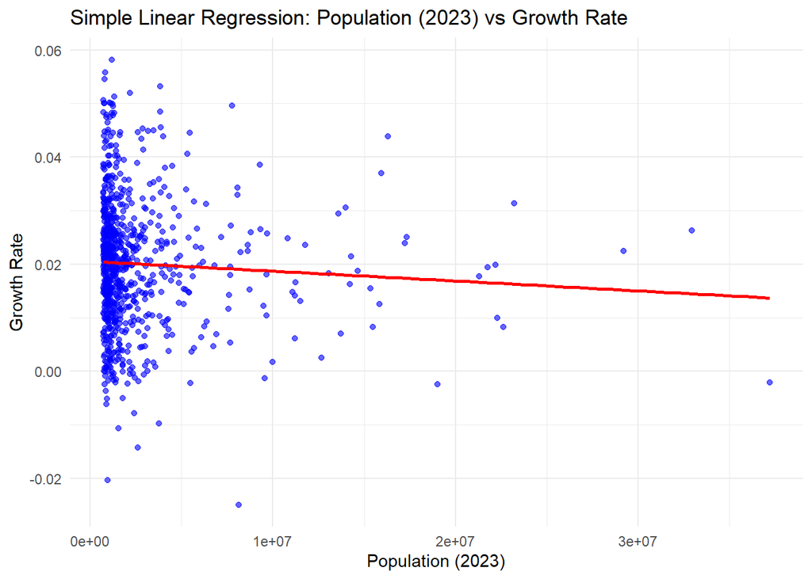

```r
# Plot the relationship and regression line
p <- ggplot(data, aes(x = `Population (2023)`, y = `Growth Rate`)) +
  geom_point(color = "blue", alpha = 0.6) +
  geom_smooth(method = "lm", se = FALSE, color = "red", size = 1) +
  ggtitle('Simple Linear Regression: Population (2023) vs Growth Rate') +
  theme_minimal()

# Print the plot
print(p)
```

### Visualization Insights

- The scatter plot and regression line indicate that there is very little relationship between the population in 2023 and the growth rate. The regression line is almost flat, reinforcing the low R² value.

```r
# Add predictions to the data frame
data$Predicted_Growth_Rate <- predictions

# Display the first few rows of the data frame with predictions using flextable
flextable_data <- head(data)
ft <- flextable(flextable_data)
ft <- autofit(ft)
ft <- set_caption(ft, "First Few Rows of Data Frame with Predicted Growth Rates")

# Print the flextable
ft
```

First Few Rows of Data Frame with Predicted Growth Rates

| City | Country | Continent | Population (2024) | Population (2023) | Growth Rate | Log_Population_2023 | Log_Population_2024 | Predicted_Growth_Rate |
| --- | --- | --- | --- | --- | --- | --- | --- | --- |
| Tokyo | Japan | Asia | 37,115,035 | 37,194,105 | -0.0021 | 17.43166 | 17.42953 | 0.01372025 |
| Delhi | India | Asia | 33,807,403 | 32,941,309 | 0.0263 | 17.31024 | 17.33619 | 0.01450219 |
| Shanghai | China | Asia | 29,867,918 | 29,210,808 | 0.0225 | 17.19005 | 17.21230 | 0.01518810 |
| Dhaka | Bangladesh | Asia | 23,935,652 | 23,209,616 | 0.0313 | 16.96008 | 16.99088 | 0.01629152 |
| Sao Paulo | Brazil | South America | 22,806,704 | 22,619,736 | 0.0083 | 16.93433 | 16.94257 | 0.01639998 |
| Cairo | Egypt | Africa | 22,623,874 | 22,183,201 | 0.0199 | 16.91485 | 16.93452 | 0.01648024 |

The simple linear regression model shows that the population in 2023 is not a strong predictor of the growth rate. This suggests that other factors might play a more significant role in determining the growth rate of cities. Let’s add more explanatory variables and predict the growth rate using multiple regression.

My understanding of SLR has been improved significantly, knowing when to use it, evaluate SLR models, and know if it’s performing well and explain the model.

### Multiple Linear Regression

In this section, we will develop a multiple linear regression model to predict the growth rate of cities. The dependent variable in this model is the `Growth Rate`, and the independent variables include `Population (2023)`, `Population (2024)`, `Continent`, and `Country`. We aims to provide a more comprehensive understanding of the factors influencing city growth rates and to predict future growth rates.

```r
# Convert categorical variables to factors
data$Continent <- as.factor(data$Continent)
data$Country <- as.factor(data$Country)

# Data preparation: create additional variables if needed
data$Log_Population_2023 <- log(data$`Population (2023)`)
data$Log_Population_2024 <- log(data$`Population (2024)`)
```

```r
# Develop a multiple linear regression model
multiple_model <- lm(`Growth Rate` ~ `Population (2023)` + `Population (2024)` + Continent + Country, data = data)

# Summarize the model
summary(multiple_model)
```

```
##
## Call:
## lm(formula = `Growth Rate` ~ `Population (2023)` + `Population (2024)` +
##     Continent + Country, data = data)
##
## Residuals:
##        Min         1Q     Median         3Q        Max
## -0.0198569 -0.0027514 -0.0001497  0.0018576  0.0235360
##
## Coefficients: (4 not defined because of singularities)
##                               Estimate Std. Error t value Pr(>|t|)
## (Intercept)                  1.618e-02  5.359e-03   3.020 0.002623 **
## `Population (2023)`         -3.148e-08  4.613e-09  -6.823 2.02e-11 ***
## `Population (2024)`          3.081e-08  4.533e-09   6.796 2.41e-11 ***
## ContinentAsia                1.299e-02  7.584e-03   1.712 0.087351 .
## ContinentEurope              6.977e-03  9.677e-03   0.721 0.471188
## ContinentNorth America      -1.540e-02  5.517e-03  -2.791 0.005414 **
## ContinentOceania            -3.966e-03  7.578e-03  -0.523 0.600870
## ContinentSouth America      -2.757e-03  5.683e-03  -0.485 0.627721
## CountryAlgeria               6.476e-04  6.562e-03   0.099 0.921423
## CountryAngola                2.533e-02  5.793e-03   4.373 1.42e-05 ***
## CountryArgentina            -1.209e-03  2.898e-03  -0.417 0.676751
## CountryArmenia              -2.602e-02  7.588e-03  -3.429 0.000643 ***
## CountryAustralia             9.923e-04  5.870e-03   0.169 0.865823
## CountryAustria              -1.461e-02  9.683e-03  -1.509 0.131874
## CountryAzerbaijan           -1.542e-02  7.585e-03  -2.033 0.042433 *
## CountryBangladesh           -2.316e-03  5.788e-03  -0.400 0.689194
## CountryBelarus              -1.841e-02  9.685e-03  -1.901 0.057709 .
## CountryBelgium              -1.806e-02  8.910e-03  -2.027 0.043036 *
## CountryBenin                 3.224e-02  7.580e-03   4.254 2.41e-05 ***
## CountryBolivia               5.671e-03  3.628e-03   1.563 0.118464
## CountryBrazil               -1.873e-03  2.153e-03  -0.870 0.384637
## CountryBulgaria             -2.268e-02  9.683e-03  -2.343 0.019452 *
## CountryBurkina Faso          3.283e-02  7.580e-03   4.332 1.71e-05 ***
## CountryBurundi               4.066e-02  7.581e-03   5.363 1.13e-07 ***
## CountryCambodia              1.456e-03  7.580e-03   0.192 0.847721
## CountryCameroon              1.823e-02  6.575e-03   2.772 0.005730 **
## CountryCanada                1.031e-02  2.213e-03   4.657 3.88e-06 ***
## CountryChad                  2.263e-02  7.579e-03   2.986 0.002932 **
## CountryChile                -3.887e-03  3.630e-03  -1.071 0.284596
```

[output cut: 97 more lines]

```
## CountryUnited Kingdom       -1.538e-02  7.605e-03  -2.023 0.043488 *
## CountryUnited States                NA         NA      NA       NA
## CountryUruguay              -8.553e-03  5.684e-03  -1.505 0.132821
## CountryUzbekistan           -1.666e-02  7.586e-03  -2.197 0.028396 *
## CountryVenezuela                    NA         NA      NA       NA
## CountryVietnam               6.982e-04  5.788e-03   0.121 0.904022
## CountryYemen                 7.870e-03  5.874e-03   1.340 0.180764
## CountryZambia                2.418e-02  6.567e-03   3.682 0.000250 ***
## CountryZimbabwe                     NA         NA      NA       NA
## ---
## Signif. codes:  0 '***' 0.001 '**' 0.01 '*' 0.05 '.' 0.1 ' ' 1
##
## Residual standard error: 0.005358 on 659 degrees of freedom
## Multiple R-squared:  0.8374, Adjusted R-squared:  0.8054
## F-statistic: 26.11 on 130 and 659 DF,  p-value: < 2.2e-16
```

```r
# Use broom to tidy the model results
tidy_multiple_model <- tidy(multiple_model)
print(tidy_multiple_model)
```

```
## # A tibble: 135 × 5
##    term                        estimate     std.error statistic  p.value
##    <chr>                          <dbl>         <dbl>     <dbl>    <dbl>
##  1 (Intercept)             0.0162       0.00536          3.02   2.62e- 3
##  2 `Population (2023)`    -0.0000000315 0.00000000461   -6.82   2.02e-11
##  3 `Population (2024)`     0.0000000308 0.00000000453    6.80   2.41e-11
##  4 ContinentAsia           0.0130       0.00758          1.71   8.74e- 2
##  5 ContinentEurope         0.00698      0.00968          0.721  4.71e- 1
##  6 ContinentNorth America -0.0154       0.00552         -2.79   5.41e- 3
##  7 ContinentOceania       -0.00397      0.00758         -0.523  6.01e- 1
##  8 ContinentSouth America -0.00276      0.00568         -0.485  6.28e- 1
##  9 CountryAlgeria          0.000648     0.00656          0.0987 9.21e- 1
## 10 CountryAngola           0.0253       0.00579          4.37   1.42e- 5
## # ℹ 125 more rows
```

```r
# Predict growth rates using the multiple regression model
multiple_predictions <- predict(multiple_model, newdata = data)

# Add multiple regression predictions to the data frame
data$Predicted_Growth_Rate_Multiple <- multiple_predictions

# Display the first few rows of the data frame with predictions using flextable
flextable_data <- head(data)
ft <- flextable(flextable_data)
ft <- autofit(ft)
ft <- set_caption(ft, "First Few Rows of Data Frame with Predicted Growth Rates (Multiple Regression)")

# Print the flextable
ft
```

First Few Rows of Data Frame with Predicted Growth Rates (Multiple Regression)

| City | Country | Continent | Population (2024) | Population (2023) | Growth Rate | Log_Population_2023 | Log_Population_2024 | Predicted_Growth_Rate | Predicted_Growth_Rate_Multiple |
| --- | --- | --- | --- | --- | --- | --- | --- | --- | --- |
| Tokyo | Japan | Asia | 37,115,035 | 37,194,105 | -0.0021 | 17.43166 | 17.42953 | 0.01372025 | -0.022418337 |
| Delhi | India | Asia | 33,807,403 | 32,941,309 | 0.0263 | 17.31024 | 17.33619 | 0.01450219 | 0.028801990 |
| Shanghai | China | Asia | 29,867,918 | 29,210,808 | 0.0225 | 17.19005 | 17.21230 | 0.01518810 | 0.024468400 |
| Dhaka | Bangladesh | Asia | 23,935,652 | 23,209,616 | 0.0313 | 16.96008 | 16.99088 | 0.01629152 | 0.033670266 |
| Sao Paulo | Brazil | South America | 22,806,704 | 22,619,736 | 0.0083 | 16.93433 | 16.94257 | 0.01639998 | 0.002158775 |
| Cairo | Egypt | Africa | 22,623,874 | 22,183,201 | 0.0199 | 16.91485 | 16.93452 | 0.01648024 | 0.018640914 |

```r
# Arrange the data by predicted growth rate in descending order
data_sorted <- data[order(-data$Predicted_Growth_Rate_Multiple), ]

# Get the top 5 cities with highest predicted growth rates
top_cities <- head(data_sorted, 5)

# Display the top 5 cities with flextable
top_flextable <- flextable(top_cities)
top_flextable <- autofit(top_flextable)
top_flextable <- set_caption(top_flextable, "Top 5 Cities by Predicted Growth Rate (Multiple Regression)")

# Print the flextable
top_flextable
```

Top 5 Cities by Predicted Growth Rate (Multiple Regression)

| City | Country | Continent | Population (2024) | Population (2023) | Growth Rate | Log_Population_2023 | Log_Population_2024 | Predicted_Growth_Rate | Predicted_Growth_Rate_Multiple |
| --- | --- | --- | --- | --- | --- | --- | --- | --- | --- |
| Bujumbura | Burundi | Africa | 1,277,050 | 1,206,767 | 0.0582 | 14.00346 | 14.06006 | 0.02033709 | 0.05820000 |
| Kinshasa | DR Congo | Africa | 17,032,322 | 16,315,534 | 0.0439 | 16.60763 | 16.65062 | 0.01755910 | 0.05580308 |
| Kampala | Uganda | Africa | 4,050,826 | 3,846,102 | 0.0532 | 15.16257 | 15.21443 | 0.01985181 | 0.05320000 |
| Dar Es Salaam | Tanzania | Africa | 8,161,231 | 7,775,865 | 0.0496 | 15.86654 | 15.91491 | 0.01912926 | 0.05242066 |
| Bobo Dioulasso | Burkina Faso | Africa | 1,185,053 | 1,128,646 | 0.0500 | 13.93653 | 13.98530 | 0.02035145 | 0.05000000 |

```r
# Get the bottom 5 cities with lowest predicted growth rates
bottom_cities <- tail(data_sorted, 5)

# Display the bottom 5 cities with flextable
bottom_flextable <- flextable(bottom_cities)
bottom_flextable <- autofit(bottom_flextable)
bottom_flextable <- set_caption(bottom_flextable, "Bottom 5 Cities by Predicted Growth Rate (Multiple Regression)")

# Print the flextable
bottom_flextable
```

Bottom 5 Cities by Predicted Growth Rate (Multiple Regression)

| City | Country | Continent | Population (2024) | Population (2023) | Growth Rate | Log_Population_2023 | Log_Population_2024 | Predicted_Growth_Rate | Predicted_Growth_Rate_Multiple |
| --- | --- | --- | --- | --- | --- | --- | --- | --- | --- |
| Bucharest | Romania | Europe | 1,767,520 | 1,776,385 | -0.0050 | 14.39009 | 14.38509 | 0.02023236 | -0.005000000 |
| Beirut | Lebanon | Asia | 2,402,485 | 2,421,354 | -0.0078 | 14.69984 | 14.69201 | 0.02011377 | -0.007800000 |
| Osaka | Japan | Asia | 18,967,459 | 19,013,434 | -0.0024 | 16.76066 | 16.75824 | 0.01706305 | -0.009216816 |
| New York | United States | North America | 7,931,147 | 8,133,522 | -0.0249 | 15.91150 | 15.88631 | 0.01906350 | -0.010895295 |
| Tokyo | Japan | Asia | 37,115,035 | 37,194,105 | -0.0021 | 17.43166 | 17.42953 | 0.01372025 | -0.022418337 |

## Mutiple Linear Regression Model Evaluation

### Predicted Growth Rates

From the predictions table:

#### Highest Predicted Growth Rates

- **Bujumbura from Africa (Burundi)** is predicted to have the highest growth rate of 0.0582.
- **Kinshasa from Africa (DR Congo)** follows closely behind.

### Visualization Insights

**Actual vs predicted growth rates**

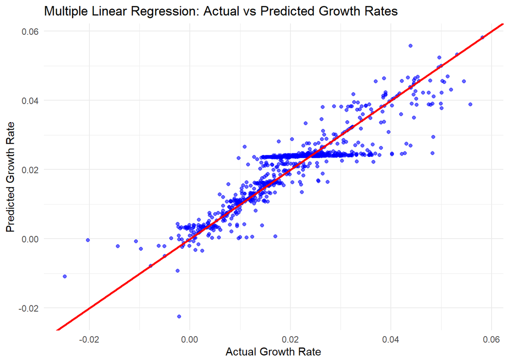

```r
# Plot the actual vs predicted growth rates
p <- ggplot(data, aes(x = `Growth Rate`, y = Predicted_Growth_Rate_Multiple)) +
  geom_point(color = "blue", alpha = 0.6) +
  geom_abline(intercept = 0, slope = 1, color = "red", size = 1) +
  ggtitle('Multiple Linear Regression: Actual vs Predicted Growth Rates') +
  xlab('Actual Growth Rate') +
  ylab('Predicted Growth Rate') +
  theme_minimal()

# Print the plot
print(p)
```

- **Scatter Plot (Actual vs Predicted Growth Rates)**

The scatter plot shows a strong alignment along the red diagonal line, indicating that the model’s predictions are generally close to the actual values.

**Residual plot**

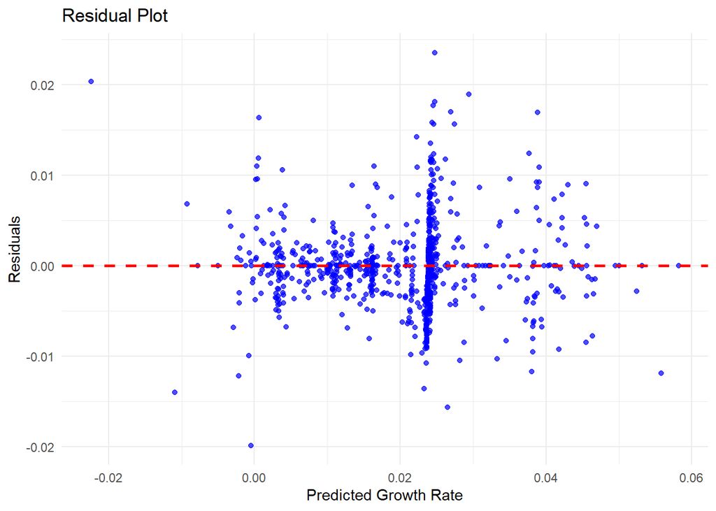

```r
# Calculate residuals
residuals <- data$`Growth Rate` - data$Predicted_Growth_Rate_Multiple

# Add residuals to the data frame
data$Residuals <- residuals

# Residual plot
p <- ggplot(data, aes(x = Predicted_Growth_Rate_Multiple, y = Residuals)) +
  geom_point(color = "blue", alpha = 0.7) +
  geom_hline(yintercept = 0, color = "red", linetype = "dashed", size = 1) +
  ggtitle('Residual Plot') +
  xlab('Predicted Growth Rate') +
  ylab('Residuals') +
  theme_minimal()

# Print the plot
print(p)
```

- **Residual Plot**

### Logistic Regression

First created a threshold for the low and high using the mediam of `growth rate` to turn the regression problem to classification problem. This was initiated to predict cities with low or high growth rate

```r
# Create a binary target variable based on the median growth rate
median_growth_rate <- median(data$`Growth Rate`)
data$Growth_Category <- ifelse(data$`Growth Rate` > median_growth_rate, 1, 0)

# Convert categorical variables to factors
data$Continent <- as.factor(data$Continent)
data$Country <- as.factor(data$Country)

# Step 2: Feature Selection
# Select relevant features for the classification model
features <- c("Population (2023)", "Population (2024)", "Continent", "Country")
df <- data[, c(features, "Growth_Category")]

# Step 3: Model Development
# Split the data into training and testing sets
set.seed(123)  # For reproducibility
split <- sample.split(df$Growth_Category, SplitRatio = 0.8)
training_set <- subset(df, split == TRUE)
testing_set <- subset(df, split == FALSE)

# Ensure the levels of the factor variables in the test set match those in the training set
training_set$Continent <- factor(training_set$Continent)
training_set$Country <- factor(training_set$Country)
testing_set$Continent <- factor(testing_set$Continent, levels = levels(training_set$Continent))
testing_set$Country <- factor(testing_set$Country, levels = levels(training_set$Country))

# Drop rows in the testing set that contain new levels
testing_set <- testing_set[!is.na(testing_set$Continent) & !is.na(testing_set$Country), ]

# Develop and fit the logistic regression model
logistic_model <- glm(Growth_Category ~ ., data = training_set, family = binomial)

# Step 4: Model Evaluation
# Predict the probabilities on the testing set
probabilities <- predict(logistic_model, newdata = testing_set, type = "response")

# Convert probabilities to binary predictions
predictions <- ifelse(probabilities > 0.5, 1, 0)

# Calculate accuracy, precision, recall, and F1 score
accuracy <- sum(predictions == testing_set$Growth_Category) / nrow(testing_set)
precision <- sum(predictions == 1 & testing_set$Growth_Category == 1) / sum(predictions == 1)
recall <- sum(predictions == 1 & testing_set$Growth_Category == 1) / sum(testing_set$Growth_Category == 1)
f1 <- 2 * (precision * recall) / (precision + recall)

# Calculate ROC-AUC
pred <- prediction(probabilities, testing_set$Growth_Category)
perf <- performance(pred, "tpr", "fpr")
auc <- performance(pred, measure = "auc")
roc_auc <- auc@y.values[[1]]

# Print the evaluation metrics
print(paste("Accuracy:", round(accuracy, 3)))
```

```
## [1] "Accuracy: 0.883"
```

```r
print(paste("Precision:", round(precision, 3)))
```

```
## [1] "Precision: 0.877"
```

```r
print(paste("Recall:", round(recall, 3)))
```

```
## [1] "Recall: 0.889"
```

```r
print(paste("F1 Score:", round(f1, 3)))
```

```
## [1] "F1 Score: 0.883"
```

```r
print(paste("ROC-AUC:", round(roc_auc, 3)))
```

```
## [1] "ROC-AUC: 0.882"
```

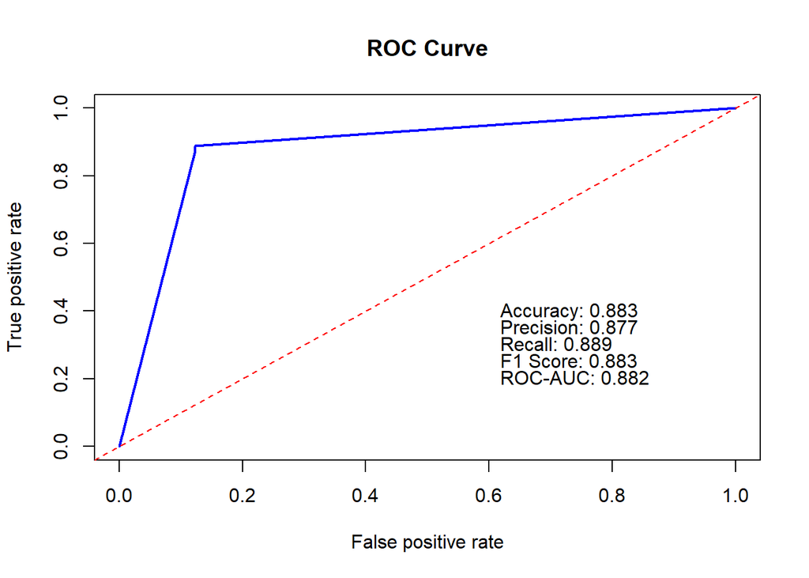

```r
# Plot ROC curve with evaluation metrics
plot(perf, col = "blue", lwd = 2, main = "ROC Curve")
abline(a = 0, b = 1, lty = 2, col = "red")
text(0.6, 0.4, paste("Accuracy:", round(accuracy, 3)), pos = 4)
text(0.6, 0.35, paste("Precision:", round(precision, 3)), pos = 4)
text(0.6, 0.3, paste("Recall:", round(recall, 3)), pos = 4)
text(0.6, 0.25, paste("F1 Score:", round(f1, 3)), pos = 4)
text(0.6, 0.2, paste("ROC-AUC:", round(roc_auc, 3)), pos = 4)
```

```r
# Print the summary of the logistic regression model
summary(logistic_model)
```

```
##
## Call:
## glm(formula = Growth_Category ~ ., family = binomial, data = training_set)
##
## Coefficients: (4 not defined because of singularities)
##                               Estimate Std. Error z value Pr(>|z|)
## (Intercept)                  2.074e+03  3.573e+05   0.006    0.995
## `Population (2023)`         -3.082e-01  2.499e+00  -0.123    0.902
## `Population (2024)`          3.022e-01  2.451e+00   0.123    0.902
## ContinentAsia               -5.060e+03  3.938e+05  -0.013    0.990
## ContinentEurope             -2.958e+04  5.958e+05  -0.050    0.960
## ContinentNorth America      -1.300e+03  3.603e+05  -0.004    0.997
## ContinentOceania             1.969e+03  5.051e+05   0.004    0.997
## ContinentSouth America      -5.595e+02  3.705e+05  -0.002    0.999
## CountryAngola               -9.235e+03  3.865e+05  -0.024    0.981
## CountryArgentina             8.180e+02  2.029e+05   0.004    0.997
## CountryAustralia             3.063e+02  3.813e+05   0.001    0.999
## CountryAzerbaijan            7.835e+03  3.969e+05   0.020    0.984
## CountryBangladesh            2.183e+03  1.776e+05   0.012    0.990
## CountryBelarus               3.749e+04  6.245e+05   0.060    0.952
## CountryBelgium               3.262e+04  5.315e+05   0.061    0.951
## CountryBolivia              -1.453e+03  5.138e+05  -0.003    0.998
## CountryBrazil                4.532e+02  1.080e+05   0.004    0.997
## CountryBulgaria              3.534e+04  6.161e+05   0.057    0.954
## CountryBurundi              -1.609e+04  5.203e+05  -0.031    0.975
## CountryCambodia             -4.989e+03  3.921e+05  -0.013    0.990
## CountryCameroon             -2.010e+04  4.386e+05  -0.046    0.963
## CountryCanada                1.300e+03  9.894e+04   0.013    0.990
## CountryChile                 1.161e+03  2.478e+05   0.005    0.996
## CountryChina                 2.975e+03  1.629e+05   0.018    0.985
## CountryColombia              1.352e+03  1.303e+05   0.010    0.992
## CountryCosta Rica            1.730e+03  3.606e+05   0.005    0.996
## CountryCuba                  9.630e+03  5.107e+05   0.019    0.985
## CountryDenmark               3.264e+04  6.062e+05   0.054    0.957
## CountryDR Congo             -8.985e+03  3.729e+05  -0.024    0.981
## CountryEcuador               1.162e+03  2.494e+05   0.005    0.996
## CountryEgypt                -1.922e+03  3.875e+07   0.000    1.000
## CountryEl Salvador           3.641e+03  3.615e+05   0.010    0.992
## CountryEritrea              -7.463e+03  5.072e+05  -0.015    0.988
## CountryEthiopia             -4.294e+04  6.125e+05  -0.070    0.944
```

[output cut: 81 more lines]

```
## CountryUruguay               6.935e+03  3.749e+05   0.018    0.985
## CountryUzbekistan            9.290e+03  3.991e+05   0.023    0.981
## CountryVenezuela                    NA         NA      NA       NA
## CountryVietnam              -7.977e+02  2.087e+05  -0.004    0.997
## CountryYemen                        NA         NA      NA       NA
## CountryZambia               -6.375e+03  3.995e+05  -0.016    0.987
## CountryZimbabwe             -2.675e+02  5.048e+05  -0.001    1.000
##
## (Dispersion parameter for binomial family taken to be 1)
##
##     Null deviance: 8.7614e+02  on 631  degrees of freedom
## Residual deviance: 9.5399e-05  on 514  degrees of freedom
## AIC: 236
##
## Number of Fisher Scoring iterations: 25
```

### Reflection

In using both SLR and MLR in this section, have learned to apply the appropriate generalized linear model for a specific data context by analyzing population growth rates and selecting suitable models such as simple and multiple linear regressions, as well as logistic regression, I have applied appropriate generalized linear models to understand and predict data trends.

## Model Summary and Evaluation Metrics (Logistic Regression)

- **Accuracy:** 0.883  
  This metric indicates that the model correctly predicts the growth category of cities 88.3% of the time.
- **Precision:** 0.877  
  87.7% of the predictions that the growth rate is high are accurate.
- **Recall:** 0.889  
  The model correctly identifies 88.9% of the high-growth cities.
- **F1 Score:** 0.883  
  An F1 score of 0.883 indicates a good balance between precision and recall.
- **ROC-AUC:** 0.882  
  An AUC of 0.882 indicates a high level of discrimination between the growth categories. The model’s performance in distinguishing between high-growth and low-growth cities.

## Key Findings

- **High Variability in Growth Rates Across Continents:** Africa shows the highest variability in growth rates, indicating diverse growth patterns among its cities.
- **Significance of Multiple Factors:** The multiple regression model, with an R² of approximately 0.8374, demonstrates that a combination of factors (Population in 2023, Population in 2024, Continent, and Country) provides a better prediction of growth rates compared to a single factor.
- **Logistic Regression Performance:** The logistic regression model effectively categorizes cities into high and low growth categories with high accuracy, precision, recall, and ROC-AUC, indicating its reliability in classification tasks.

### Reflection

I explored different modeling techniques and selected the best models based on the data’s characteristics. This process included evaluating models based on their performance and suitability for the given data, demonstrating my ability to conduct model selection.

### Reflection

Through detailed analysis and visualizations, I communicated the insights from the data effectively. The correlation and distribution analysis provided clear, interpretable results that could be understood by a general audience.

### Reflection

I have used R quite well for importing data, performing correlation and distribution analysis, and visualizing results. This hands-on experience with R has enhanced my proficiency in using the programming software to fit and assess statistical models.

Finally, my participation in class was a bit slow since I started the course late and was trying to catch up. This limited my ability to participate on the Teams platform, but I was in constant contact with one of my classmates. We shared ideas and helped each other. The entirely online format was a new experience for me, and I enjoyed the course tutorials, which also contributed to my slow participation because I wanted to complete most of the course material before sharing with my classmate.

Additionally, I aimed to complete six hours of study per week but found that I was only able to do so for three weeks. Despite this, I tracked my progress by completing the tutorials, which was a significant achievement for me.